# Safety in Numbers: Downsizing and the Deinstitutionalization of Permanent Employment in Japan

Converted from PDF `Ahmadjian-PermanentEmploymentJapan-2001-ASQ.pdf` · 33 pages · anchors: page `#pN`, block `#pN-bK`

Page 1

#### **Safety in Numbers:**

**Downsizing and the Deinstitutionalization of Permanent Employment in Japan**

**Christina L. Ahmadjian Hitotsubashi University Patricia Robinson University of California at Berkeley**

**? 2001 by Cornell University. 0001 -8392/01/4604-0622/$3.00.**

#### **0**

**We are grateful for helpful comments on various drafts from Marta Elvira, Henrich Greve, Don Hambrick, Paul Ingram, Kiy- ohiko Ito, Rita McGrath, Tom Roehl, Adri- an Tschoegl, and seminar participants at U.C. Berkeley. Appreciation also goes to Eleanor Westney for encouraging research in this area. We also thank Dan Brass, Linda Johanson, and three anony- mous ASQ reviewers.**

**This study examines the role of downsizing in the deinsti- tutionalization of permanent employment among publicly**

**listed companies in Japan between 1990 and 1997. We found that although economic pressure triggered down- sizing, social and institutional pressures shaped the pace and process by which downsizing spread. Large, old, wholly domestically owned, and high-reputation Japan- ese firms were resistant to downsizing at first, as were firms with high levels of human capital, as reflected by**

**high wages, but these social and institutional pressures diminished as downsizing spread across the population. We argue that this breakdown of social constraints was due to a safety-in-numbers effect: as downsizing became more prominent, the actions of any single firm were less likely to be noticed and criticized, and the effect of the institutional factors that once constrained downsizing diminished.0**

**While population-level change has long been a central con- cern of organizational theory, most theory and research focuses on the adoption and diffusion of new practices, with few studies examining how organizational practices are elimi- nated across an organizational population. In particular, there is a paucity of literature on deinstitutionalization, the process by which deeply entrenched practices give way to new inno- vations (exceptions include Davis, Diekmann, and Tinsley,**

**1994; Greve, 1995; Kraatz and Zajac, 1996). Neoinstitutional- ist theory tends to concentrate on the process by which new practices become widely disseminated and persist regardless of the economic rationale for them (DiMaggio and Powell,**

**1983; Scott, 1995). Research on institutionalization often "implies that institutionalization is a once-and-for-all process" (Davis, Diekmann, and Tinsley, 1994: 550). Yet processes of both institutionalization and deinstitutionalization drive change: often, new practices cannot be adopted unless the old ones are left behind. A more complete understanding of organizational and economic change requires us to under- stand how institutionalized practices erode and make way for the new.**

**Theory and empirical research have begun to illuminate the process by which organizational practices and structures are transformed through deinstitutionalization and the closely related processes of abandoning existing practices and adopt- ing new, illegitimate ones. Recent research highlights the economic, technical, political, and social antecedents of dein- stitutionalization and provides evidence that institutionalized practices and structures are far from stable (Oliver, 1992). Technical and economic pressures, for example, lead organi- zations to adopt practices diametrically opposed to long-held organizational values, as Kraatz and Zajac (1996) found in their study of the adoption of professional programs by U.S. liberal arts colleges. A changing regulatory environment and the shifting dynamics of power and resources can transform even the most thoroughly entrenched notions of the corpora- tion and its appropriate form, as evidenced by the wholesale breakup of U.S. business conglomerates through takeover, leveraged buyouts, and investor pressure (Davis, Diekmann, and Tinsley, 1994). Social processes further hasten deinstitu- tionalization, as organizations seek information from those**

#### **622/Administrative Science Quarterly, 46 (2001): 622-654**

Page 2

**Safety in Numbers**

**around them on the costs and benefits of abandoning exist- ing practices and adopting new ones (Greve, 1995; Kraatz, 1998). While existing research has begun to address factors that trigger deinstitutionalization, researchers have paid less attention to the specific economic, social, and institutional forces that impede and promote it or to how the influence of these forces changes as deinstitutionalization gains momen- tum over time. Given that a practice is institutionalized when**

**it spreads and persists as a result of social factors, above and beyond its technical or economic efficacy (Meyer and Rowan, 1977; DiMaggio and Powell, 1983), deinstitutionalization implies that these social factors somehow lose their grip. But what causes these factors to fall away, and by what route does deinstitutionalization spread through an organizational field? The fate of permanent employment during the sluggish Japanese economy of the 1990s provides an excellent case**

**in which to examine this question.**

#### **This paper documents the process by which downsizing**

**became increasingly prevalent in Japan in the 1990s, focus- ing on the effect of both economic and institutional pressures on the spread of downsizing among firms. While scholars have documented how institutional constraints slow or stop the adoption of new, illegitimate, or divergent practices**

**(Leblebici et al., 1991; Haveman, 1993b; D'Aunno, Succi, and Alexander, 2000), and a large literature traces how new prac- tices diffuse across organizational fields (e.g., Galaskiewicz and Wasserman, 1989; Davis, 1991; Burns and Wholey,**

**1993; Haunschild, 1993; Haveman, 1993a), very rarely have these two processes been examined concurrently. Although the relative roles of institutional and economic factors in orga- nizational change have been the subject of much debate (e.g., Kraatz and Zajac, 1996), organizational researchers are only recently beginning to examine the interaction between social and economic effects over time in large pooled data sets (D'Aunno, Succi, and Alexander, 2000).**

**PERMANENT EMPLOYMENT IN JAPAN Permanent employment refers to "the practice whereby an employee enters a company after school graduation, receives**

**623/ASQ, December 2001**

Page 3

**in-company training, and remains an employee of the same company until the retirement age of fifty-five" (Cole, 1979:**

**11). In much of the postwar period, large Japanese firms had an implicit contract with their employees to provide them with employment until age 55 (Abegglen, 1958; Dore, 1973; Clark, 1979). A constant influx of lower-wage and lower- skilled new graduates bolstered the permanent employment system, and mid-career hiring was virtually unknown. While the retirement age in Japan was early, firms continued to**

**honor their obligation to employees in the form of transfers to affiliated firms.**

**In the years leading up to World War 11, Japanese companies began to establish pay structures to retain employees and reward performance (Gordon, 1985). Permanent employment became further institutionalized in the years following World War 11, when large Japanese employers responded to severe**

**labor unrest and militant unions by assuring their employees a decent living and stable job in return for their cooperation (Taira, 1970; Dore, 1973; Gordon, 1985). The sense of perma- nent employment as a moral imperative developed further in the postwar period, when Japanese companies and the state**

**legitimized the relatively new system of permanent employ- ment by attributing to it aspects of traditional Japanese cul- ture, such as collectivism and hierarchical and paternalistic interpersonal relationships (Cole, 1979). Although, according to Japanese labor law, a firm was free to fire an employee upon 30 days notice, judicial precedents made it very difficult to terminate employees. Japanese courts tended to uphold a firm's decision to fire only when there were strong economic pressures, when the firm had secured the agreement of the labor union, selected candidates for dismissal in a fair man- ner, and had exhausted all other methods of reducing labor costs (Sugeno, 1992).**

**During the 1980s, the permanent employment system became further legitimated by economists and management experts, who argued that permanent employment and other Japanese management practices were not merely distinctive Japanese practices but superior ways of doing business.**

**Economists argued that permanent employment encouraged collaboration, development of firm-specific skills, and loyalty (Aoki, 1988). Foreign scholars touted the advantages of the Japanese system for Western industrialized nations, and such praise from foreigners gained wide exposure in Japan (Dore, 1973; Vogel, 1979). Thus, by the 1980s, virtually all large Japanese firms assured permanent employment to male employees hired directly from high school or college (called seishain, or regular employees, to distinguish them from part-time and contract labor). Permanent employment was the rule among firms listed on the first section of the Tokyo Stock Exchange (Brown et al., 1997), and some observers of the Japanese employment system have argued that permanent employment extended more deeply into smaller firms than often acknowledged (Cole, 1979).**

**The Economic Crisis of the 1990s The permanent employment system came into question as four decades of postwar economic growth ended with the**

#### **6241ASQ, December 2001**

Page 4

**Safety in Numbers**

**fall of the stock market and the burst of the bubble economy in the early 1990s. In the face of reduced sales, declining lev- els of growth, increased international competition, and a strong yen, managers increasingly believed that Japanese firms were overstaffed. Estimates of excess employees**

**reached six million (Eisenstodt, 1995).**

**Japanese firms historically dealt with declining performance through wage adjustments, reduction of overtime, and dis-**

**missal of contract laborers (Mroczkowski and Hanaoka, 1997). This is not to say that downsizing, through reduced hiring, early retirements, and dispatch of employees to affili- ated firms (shukkou), was unknown: downsizing was wide- spread in the 1970s in response to the oil shocks. Downsiz- ing during the 1970s, however, was in response to a specific price shock and occurred in the context of industrial planning and active state guidance, strong intercorporate groups, and respected main banks. It occurred through the shutdown of entire industries and transfer of employees from troubled firms to better-performing affiliates (see Dore, 1986; Sheard,**

**1991). Labor-force reductions during this period were not seen as a retreat from permanent employment, and their experience during the first oil shock made many firms reluc- tant to attempt downsizing again. A report by the Bank of Japan (1 994: 130) commented:**

**Behind the fact that Japanese firms didn't make larger cuts in regu- lar employees from the second oil shock and after is that companies that carried out employment adjustments until then suffered a decline in corporate image and a worsening in relations with their unions. Many have suggested that these tangible and intangible costs were greater than anticipated.**

**Downsizing in the 1 990s took on a different flavor from that during the first oil shock. While firms used many of the same techniques favored in the earlier periods-such as dismissal of contract and part-time labor and dispatch of employees to affiliates-there were distinct differences. Direct layoffs, though still a small proportion of total dismissals, became more common. According to Ministry of Labor statistics, the percentage of job separations among firms with over 1000 employees due to management circumstances (as opposed to retirement and other individual circumstances) increased from 2.3 percent in 1980 to 9.3 percent in 1998 (Ministry of**

**Labor, 2000: 521). The unemployment rate increased from approximately 2.2 percent in 1990 to 4.2 percent in early**

**1998 (and on to 5 percent in 2001) (Ministry of Labor, 1996, 2001).**

**Along the path to layoffs, firms also resorted to hiring freezes. While employers may have viewed hiring cuts as a means to protect the jobs of existing employees, hiring freezes were nevertheless threats to the permanent employ- ment system in several ways. Since the permanent employ- ment system depended on successive cohorts of new employees entering each year, a hiring freeze meant <sup>a</sup>gaping hole in a firm's age and promotion hierarchy. Furthermore, firms that curtailed or drastically reduced hiring risked bad publicity and poor future recruiting prospects. Firms tended to develop very close relationships with a set of schools from**

**625/ASQ, December 2001**

Page 5

**which they recruited, and hiring cuts violated an implicit agreement to a steady number of annual hires (Rohlen,**

**1983). Firms had tried hiring cuts during the oil crisis but soon backed away as they found that hiring cuts were "dis- tasteful" and costly to their reputations (Usui and Colignon,**

**1996).**

**Perhaps more striking than the actual downsizing tactics was their psychological impact. In the words of one employee commenting on an involuntary early retirement program at**

**his firm, "A few days ago, these managers would have been looking forward to a comfortable last few years. Now they are told the company doesn't want them. Who will be next?" (Thomson, 1993: 24). Newspapers highlighted these con- cerns with heart-rending series on downsized employees and their struggle to retain their dignity and economic status.**

**Increasing suicide rates were attributed to economic insecuri- ty. Yet despite the negative psychological impact of labor- force reductions, Japanese employers increasingly believed that downsizing was a necessary step, and the age of perma- nent employment was over. Elite business organizations called for a new era of "flexibility" in employment (e.g.,**

**Keizai Doyukai, 1994). Over 70 percent of the Japanese exec- utives who responded to a 1998 poll agreed that their firms needed to revise the permanent employment system. Ninety-five percent said that across the Japanese economy as a whole, permanent employment was changing either drastically (22.6 percent) or to some extent (LTCBR Consult- ing, 1998). Thus, in the 1990s, a belief that labor-force reduc- tions were a prerequisite for economic renewal came face to face with the institutionalized realities of the system. Labor- force reductions in the 1990s were a direct threat to the sys- tem of permanent employment. First, more than ever before, they involved direct layoffs or, at least, strong pressure on employees to retire. Second, hiring reductions eliminated an entire cohort of young employees and threatened the struc- ture of age-based wage and promotion at the foundation of the permanent employment system. Third, employees, the media, and the general public viewed the downsizings of the 1 990s as nails in the coffin of the permanent employment system and as a bad omen for their own careers. The story of how Japanese firms in the 1990s resolved this tension between the perceived economic benefits of labor reductions and deeply permanent employment begins with economic pressure.**

**Economic Pressures as Triggers to Deinstitutionalization Researchers of deinstitutionalization have argued that eco- nomic and technical factors cause organizations to abandon deeply institutionalized practices (Oliver, 1992). Changing con- sumer demand causes organizations to adopt practices opposed to long-held principles, as in the case of adoptions of professional programs by liberal arts colleges in the U.S. (Kraatz and Zajac, 1996). Poor performance leads firms to abandon long-maintained practices, imprinted from the earli- est days of founding (Boeker, 1989). Environmental stimuli, including product demand, technology, and the competitive environment, transform organizational strategy and structure**

**626/ASQ, December 2001**

Page 6

**Safety in Numbers**

**(Chandler, 1962; Miller and Friesen, 1984; Tushman and Anderson, 1986).**

**Similar economic pressures may have triggered the deinsti- tutionalization of permanent employment. Several metrics**

**likely signaled declining performance and the need to reduce headcount. First, declining sales growth indicated economic trouble and a need to retrench and reduce costs in a business environment in which managers pay close attention to sales growth (Abegglen and Stalk, 1985). While Japanese managers traditionally have not displayed the**

**same relentless concern for profit maximization as Ameri- can managers, low profitability, as measured by return on assets, was also an important indicator of financial distress and often triggered restructuring and reorganization (Kang and Shivdasani, 1997). Further, we predict that firms were more likely to downsize when low performance was trace- able to high labor costs. Surveys of managers during this period indicated a wide consensus that firms were over- staffed (Ministry of Labor, 1995). A low ratio of profits to employees reflected a high degree of redundancy (Budros, 1997). Thus, we hypothesize:**

**Hypothesis la (Hla): The lower the performance, as measured by return on assets and sales growth, the more likely a firm was to downsize.**

**Hypothesis lb (Hlb): The lower its profits per employee, the more likely a firm was to downsize.**

#### **Social and Institutional Constraints**

**While declining performance may encourage organizational change, organizations do not abandon institutionalized prac- tices merely because better options present themselves**

**(DiMaggio, 1988). Rather, social and institutional pressures shape the pace and process of change throughout an organi- zational population. Since organizations adopt and maintain institutionalized practices in order to enhance their legitimacy (DiMaggio and Powell, 1983), an organization that abandons an institutionalized practice is likely to suffer a drop in legiti- macy. This drop in legitimacy may be costly. Legitimacy enhances access to resources, including financial resources and regulatory approval (Pfeffer and Salancik, 1978), cus- tomers, and public support (Elsbach and Sutton, 1992); there- fore, organizations that have achieved high levels of legitima- cy are more likely to survive and flourish (Ruef and Scott,**

**1998). An organization is likely to weigh the very real costs of diminished legitimacy against the benefits of abandoning a deeply institutionalized practice.**

**Legitimacy comes from a number of sources. Scott (1995) identified three pillars of institutionalization that provide differ- ent bases for legitimacy and have different implications for how practices become institutionalized. The regulative pillar underscores how institutionalization is achieved and main- tained through regulations, sanctions, and monitoring. The normative pillar focuses on the norms and values that define the appropriate ways of designing and managing an organiza- tion. Finally, the cognitive pillar draws attention to how orga-**

**627/ASQ, December 2001**

Page 7

**I Since 1990, we have interviewed numer- ous Japanese managers and government officials as part of our larger research pro- gram on change in the Japanese econo- my. The interviews were open-ended and covered a range of topics concerning change and restructuring.**

**nizational practices become adopted and perpetuated because they are taken for granted as natural and appropri- ate. Our model of the spread of downsizing emphasizes the normative aspects of institutionalization. Permanent employ- ment became institutionalized as it became "infused with value" (Selznick, 1957: 17) as a normatively appropriate prac- tice, consistent with deeply held Japanese values. A firm that downsized and signaled a willingness to break with long-held implicit contracts of permanent employment was perceived to be a "bad company" (in the words of a government official that we interviewed) that had neglected its social responsibil-**

**ities.1 Both the press and public opinion enforced these norms against downsizing. In their study of downsizing in Japan in the early 1990s, Usui and Colignon (1996: 565)**

**noted, "The media and public opinion enact the standard that it is 'unnatural' for any organization to dismiss workers for economic convenience. They expect companies to honor job security for regular employees in exchange for their loyalty through good and bad times." Several managers and govern- ment officials that we interviewed suggested that companies took this negative press and public opinion accompanying downsizing very seriously. They feared that downsizing would threaten sales, as consumers would hesitate to buy from a company that had neglected its social responsibility. In the mid-1 990s, we interviewed a public relations manager of a large Japanese firm that had just been taken over by a for- eign firm. He complained about the constant phone calls from the press asking when they were planning to downsize and described his very guarded responses to them: Any hint of downsizing, he said, would immediately be front-page news, and the coverage was not likely to be complimentary.**

**Firms that had achieved high levels of legitimacy, in the sense that they were closely associated with the Japanese employment system and were expected to be stronger exemplars of this system, could be expected to resist down- sizing. Concern about the press and public opinion further suggests that firms with higher visibility-firms more likely to attract press attention because of their size, age, prestige, or other factors-were also more likely to resist change. Finally, firms that were more dependent on constituencies that val- ued conformance with legitimate practices should have been less likely to downsize. These aspects of organizational visi- bility and legitimacy are likely to be reflected in organizational size, age, reputation, wage levels, and foreign ownership. Firm size. While research in the U.S. shows only mixed sup- port for a link between legitimacy and size (Deephouse,**

**1996; Ruef and Scott, 1998), it is difficult to dispute that in Japan, the larger a firm, the greater its legitimacy. Most**

**books on Japanese business practices feature large firms as exemplars, as they were believed to adhere most closely to the Japanese employment system and best embody Japan- ese values. Because they were well known, prestigious, and believed to be good, stable employers, large firms were able to recruit graduates of top schools. Large firms were also at the core of the Japanese political economy (Dore, 1973;**

**Rohlen, 1974; Clark, 1979; Cole, 1979). They maintained close links to large financial institutions and had superior**

**628/ASQ, December 2001**

Page 8

**Safety in Numbers**

**access to funding; they had close ties to the state, and through leadership positions in peak business organizations, such as the Keidanren and trade associations, played an important role in influencing industrial and economic policy. Such core firms had much more to lose through deviant behavior than firms at the periphery (Leblebici et al., 1991). Large firms were also often under greater scrutiny by the state and general public, due to their higher visibility (Salan- cik, 1979). Furthermore, the larger a firm, the more likely its downsizing involved large numbers of people and thus, the more likely that it would attract media coverage.**

**Hypothesis 2a (H2a): The larger the firm, the less likely it was to downsize.**

**Firm age. The older an organization in Japan, the more likely it had achieved a high level of legitimacy, and thus, the more it had to lose by deviant behavior. As Hannan and Freeman (1984: 158) noted, "Nothing legitimates both individual orga- nizations and forms more than longevity. Old organizations tend to develop dense webs of exchange, to affiliate with centers of power, and to acquire an aura of inevitability." Older firms in Japan were also more closely associated with the Japanese employment system and with preserving Japanese values. Newer firms, such as Sony and Honda, considered relative newcomers in Japan, tended to be less associated with the existing system. Already seen as out- siders, and less dependent on domestic Japanese product and capital markets, these newer firms had less to lose by defying normatively accepted practices.**

**Hypothesis 2b (H2b): The older the firm, the less likely it was to downsize.**

**Firm reputation. Organizations also enhance their legitimacy through endorsements by regulatory bodies or associations**

**(Ruef and Scott, 1998). In Japan in the 1990s, the annual rankings of firms put out by Recruit, a Japanese business publisher and recruiting agency, were among the most watched and publicized measures of firm reputation. Based on surveys of recent graduates, these rankings were well**

**known and remarked upon in the business community and among the general public. Firms that attracted favorable pub-**

**licity by rating highly in these rankings were unlikely to com- promise their reputation through behavior such as downsiz- ing.**

**Hypothesis 2c (H2c): The more highly a firm ranked in the Recruit rankings, the less likely it was to downsize.**

**Wages and human capital. The degree to which an organi- zation conforms to legitimate, normatively accepted behav- iors is likely to depend on its resource dependencies (Pfeffer and Salancik, 1978). A firm that depends on stakeholders that strongly support an institutionalized practice is not likely to abandon that practice. Similarly, the greater the extent to which a firm relies on highly trained employees with firm- specific skills to solve problems and manage complex tasks and interactions with others, the less likely it is to dismiss such valuable resources. This reluctance to downsize among**

**629/ASQ, December 2001**

Page 9

**firms with high levels of human capital was likely to be partic- ularly pronounced in Japan, as human capital tended to be highly firm specific, to take many years to develop, and to be difficult, if not impossible, to transfer between firms (Aoki,**

**1988; Koike, 1988; Becker, 1993). Furthermore, a firm that downsized was likely to lose the commitment of remaining employees, who believed that they and their downsized col- leagues had been promised a job for life, or at least until retirement age.**

**High levels of human capital are likely to be reflected in a firm's wage levels. A firm that paid higher than average wages was likely to have recruited employees from top uni- versities and to have put them through rigorous, long-term training programs. Since wages in Japanese firms were largely set according to the nenkou, or age-based system, firms whose wages exceeded those of their industry average were likely to have older employees who had developed greater levels of firm-specific human capital over their long careers. Thus,**

**Hypothesis 2d (H2d): The higher a firm's wages, the less likely it was to downsize.**

**Foreign ownership. Research on institutionalization high- lights the fact that different actors in an organizational field may have different conceptions of legitimacy (Suchman, 1995). These competing notions of legitimacy were very visi- ble in the Japanese economy during the 1990s. During this period, foreign investors, specifically, U.S. and European financial institutions, became a strong presence in the Japan- ese stock market, increasing their ownership of Japanese shares from about 4 percent of all publicly traded shares in**

**1990 to about 10 percent in 1997 (Tokyo Stock Exchange, 2001).**

**While permanent employment was legitimate and appropri- ate to most Japanese investors, it was less so to foreigners.**

**In the 1980s in the United States, shareholder activism had transformed the rhetoric of corporate governance, and corpo- rations were increasingly seen as having the fundamental purpose of creating shareholder value, even at the expense of other stakeholders such as employees (Useem, 1996). Large foreign investors, usually U.S. or European institutional investors and corporations, brought this notion of "sharehold- er capitalism" to their investments in Japan. Less con- strained by conceptions of permanent employment and the Japanese system, and more influenced by U.S.-style share- holder capitalism, these foreign shareholders were likely to demand immediate attention to shareholder value.**

**Hypothesis 2e (H2e): The greater a percentage of a firm's shares held by foreigners, the more likely it was to downsize.**

**Safety in Numbers and Population-level Effects As more firms downsized across the population, the social costs of downsizing for any single firm were likely to have decreased. If a single firm downsized, its deviant behavior was likely to draw much attention and social censure. When many other firms committed the same deviant act, however,**

**630/ASQ, December 2001**

Page 10

**Safety in Numbers**

**it was less likely that any individual firm would be singled out for criticism. Furthermore, as downsizing became more wide- spread, a firm was more likely to get away with the time-hon- ored explanation of "everyone else is doing it" to justify its behavior to employees, the general public, and other impor- tant stakeholders. Thus, increasing downsizing across the**

**population would have provided safety in numbers and reduced the risk that a firm was censured for its deviant behavior. For example, in 1993, Pioneer learned the impor- tance of seeking safety in numbers the hard way, when it gave 35 senior employees a choice between early retirement and dismissal (Thomson, 1993). The announcement was pub- licized widely in the mass media as a harbinger of the end of permanent employment. Several weeks later, Pioneer retract- ed its decision, allegedly due to concern about unfavorable publicity and pressure from its labor union. Several years later, as mentions of downsizings in the business press reached thousands per year, however, similar announce- ments of downsizing by other firms went unremarked.**

**The concept of safety in numbers leads to the proposition that firms would follow the lead of other firms in the popula- tion: the more other firms downsized, the more likely any given firm was to downsize. Some firms would have been more likely to seek safety in numbers than others, however, because some firms would have felt the institutional and social constraints that discouraged downsizing more acutely than others. The more legitimacy a firm had at stake, and the**

**more visible it was in the mass media, the more likely it would refrain from downsizing until others had gone first. Thus, large, old, and high-reputation firms would have been**

**more likely to downsize only as downsizing became more widespread across the population. Firms with high invest- ments in human capital were also likely to refrain from down- sizing until others had gone first: the more that a firm was able to justify its downsizing by pointing out that competitors and business associates were doing the same, the less likely it was to lose employee commitment. Firms with higher lev- els of Japanese ownership were also likely to refrain from downsizing until others had done so, while foreign-owned firms were less likely to be constrained by prevailing notions of legitimate employment practices. Thus, we predict that firm characteristics reflecting social and institutional con- straints on downsizing moderated the effect of population downsizing on firm downsizing.**

**Hypothesis 3 (H3): The more firms in the population that down- sized, the less likely social and institutional pressures (as reflected by size, age, reputation, wage, and ownership) were to constrain downsizing.**

**1990-1997: machinery; electric and electronic equipment; shipbuilding and repairing; motor vehicles and auto parts; pre- cision equipment; construction; wholesale trade; retail trade; foods; textile products; pulp and paper; chemicals; drugs; petroleum; rubber products; stone, clay, and glass products; iron and steel; and non-ferrous metal and metal products. We**

**631/ASQ, December 2001**

Page 11

**included only firms that were publicly listed in all years of this period, omitting 32 firms that were listed in 1990 but subse- quently exited from the sample. Exits were almost all due to merger or acquisition or delisting rather than bankruptcy. Since only a very small percentage of the firms in the sample exited during this period, selection bias is unlikely to be a problem.**

#### **Variables**

**Dependent variable. The dependent variable is a downsizing event. We defined downsizing as a decrease in the number of permanent employees (excluding contract and temporary workers) of 5 percent or more between year t-1 and year t. This operationalization of downsizing has several advantages. Changes of this magnitude (over 5 percent) are more likely to occur through concentrated efforts to reduce the workforce than through attrition. Changes this large are also more likely to attract publicity. A dichotomous measure of downsizing is also easier to interpret than a continuous measure that cap- tures both an increase and a decrease in employment. Although a number of researchers have derived measures of downsizing from press reports (Budros, 1997; Lee, 1997), public announcements of downsizing in Japan do not neces- sarily capture actual downsizing rates. Close scrutiny of the Nihon Keizai Shimbun, Japan's leading economic newspaper, reveals announcements of proposed large-labor force reduc- tions rather than details of actual downsizings that have occurred. We believe that actual downsizing is best reflected in real reductions in the labor force rather than in announce- ments.**

**Freeman and Cameron (1993: 12) defined downsizing in the United States as "a set of activities, undertaken on the part of the management of an organization, designed to improve organizational efficiency, productivity, and/or competitiveness.**

**It represents strategy implemented by managers that affects the size of the firm's work and the work processes used." Consistent with this definition, downsizing in the 1990s in Japan was a result of conscious managerial decisions to reduce employment and was accomplished through reduc- tions in hiring, early retirements, sending employees to affili- ates, and, in some cases, layoffs. We were unable to distin- guish between these different means of downsizing, since these data are not available on the firm level. As we dis- cussed earlier, however, all four represent violation of the norms around permanent employment.**

**Independent variables. Return on assets is profits before taxes and extraordinary items divided by total assets. Sales growth is the percentage growth in sales between year t-1 and year t. Losses over the previous 5 years is the sum of years in the previous five years that a firm experienced loss- es. Profits per employee is the deviation from industry mean of the ratio of a firm's operation profits to total employees. All performance measures, except for sales growth, which**

**measures change over the previous year, are lagged by one year.**

**Firm size is the log of total assets. Firm age is the number of years between a firm's founding and 1990. Recruit endorse-**

**632/ASQ, December 2001**

Page 12

**Safety in Numbers**

**ment is the sum of the number of times that a firm appeared in Recruit's annual listing of the most attractive 50 firms for new graduates during the 1980s. We used data from the 1980s for several reasons. First, frequent appearance in past rankings indicates that a firm had established a substantial reputation as an employer. Second, since it is likely that downsizing behavior influenced Recruit rankings, we believe that rankings from the 1980s are a better measure of reputa- tion before downsizing.**

**Wage is the deviation from industry mean of a firm's payroll expense divided by the total number of employees. Foreign ownership is the percentage of shares held by non-Japanese shareholders. We examined the identities of these sharehold- ers for a subset of about 700 firms and found that foreign shareholders were almost exclusively large American, Euro- pean, or Australian corporations or institutional investors.**

**Population downsizing is the sum of downsizings of all firms in the population, minus the focal firm, over the previous three years; for example, population downsizing for 1990 is based on downsizings in 1987, 1988, and 1989. We divided this by the total number of firms in the population, minus the focal firm, multiplied by three, which measures the total**

**number of potential downsizing events within the population during this period. Thus, this measure can be thought of as the percentage of firm-years in which a downsizing occurred over the previous three years. While the percentage or cumu- lative number of adopters is often used in research on adop- tions of new practices, it is less appropriate in this case because we argued that population-level downsizing is likely to be influenced by a safety-in-numbers effect, as large num-**

**bers of downsizings in the recent past make any given firm's downsizing less visible. Thus, a measure of relatively recent downsizings, rather than cumulative downsizings, is more appropriate.**

**Control variables. Real GDP growth between t-1 and t mea- sures macroeconomic conditions. We used a continuous measure of calendar year to control for the passage of time. We controlled for exposure to foreign markets with a mea- sure of exports divided by sales for the previous year. Finally, we included a set of dummy variables for each industry to control for interindustry differences in propensity to down- size.**

**Analytical Approach Our data consists of a panel of 1,638 firms observed over eight years. Downsizing is an event that may or may not occur in any given year and may occur in multiple years. We employed a variation of discrete-time event history methodol- ogy (Allison, 1984; Yamaguchi, 1991). We used a panel probit model to estimate the hazard of a downsizing event in a given year in a pooled sample of each organization observed during each of the eight years:**

**633/ASQ, December 2001**

Page 13

**P(t) is the probability of a downsizing event occurring at time t. X1 is a set of time-invariant covariates, while x2 is a set of time-varying covariates. The discrete-time model is appropri- ate when information on the exact timing of an event is not available, and multiple organizations report the same event as occurring at the same time (i.e., in the same year).**

**In most cases, discrete and continuous time models produce similar results (Allison, 1984). We used a generalized estimat- ing equation approach to estimate random effects probit models (Liang and Zeger, 1986) to address the issue of unob- served heterogeneity due to repeated observations on the same firm across years and among firms in any given year. It is important to control for unobserved heterogeneity between firms because downsizing was a repeated event. Some firms downsized more than others, and if these differ- ent propensities to downsize were due to unmeasured firm- specific factors, statistical tests of resulting coefficient esti- mates could be inaccurate. Further, following the recommendation of Allison (1984), we included a variable that measures each firm's cumulative history of downsizing since 1985. We also report standard errors derived from the**

**Huber/VWhite robust estimator of variance. This estimator allowed us to obtain consistent standard errors even when the correlation structure assumed by a probit model is violat- ed. Using this estimator allows us to relax the assumption that observations within the same cluster (in our case, the same firm observed across the eight years) are uncorrelated (White, 1980).**

**By 1997, over 50 percent of the firms had downsized at least once. Larger downsizings, of 10 percent or more, though more rare, also gained momentum over time. By 1997, over 20 percent of all firms had downsized by 10 percent or more.**

**Table 2 presents descriptive statistics, and table 3 presents**

**bivariate correlations. Table 4 reports results of random effects panel probit analyses of downsizings of 5 percent or more. Model 1 includes measures of economic pressures and controls. Consistent with H1a, firms downsized in response to low return on assets and low sales growth.**

**Table 1**

#### **Annual Downsizing Rate***

| Size of downsizing | 1990 | 1991 | 1992 | 1993 | 1994 | 1995 | 1996 | 1997 |
| --- | --- | --- | --- | --- | --- | --- | --- | --- |
| 2%ormore 5%ormore 10%ormore | 175 . 059 . 027 . | 126 . 038 . 016 . | 142 . 049 . 015 . | 191 . 106 . 042 . | 311 . 159 . 074 . | 438 . 205 . 085 . | 513 . 240 . 071 . | 518 . 222 . 075 . |

NOTE: table converted from PDF layout to HTML text; cell boundaries are reconstructed. See PDF if exact alignment matters.

**634/ASQ, December 2001**

Page 14

**Safety in Numbers**

**Figure 1. Cumulative percentage of firms that downsized at least once since 1990.**

#### **60**

#### **50**

#### **40**

**0 S 30+ 5% downsizing**

#### **-A- 10% downsizing**

#### **E 3 20**

#### **10**

**1990 1991 1992 1993 1994 1995 1996 1997**

#### **Year**

**Mounting years of poor performance further increased the likelihood of downsizing. Contrary to H lb, low profits per employee did not increase a firm's likelihood of downsizing. In additional analyses, we examined an alternative measure of excess employment, sales per employee. We found no**

**Table 2**

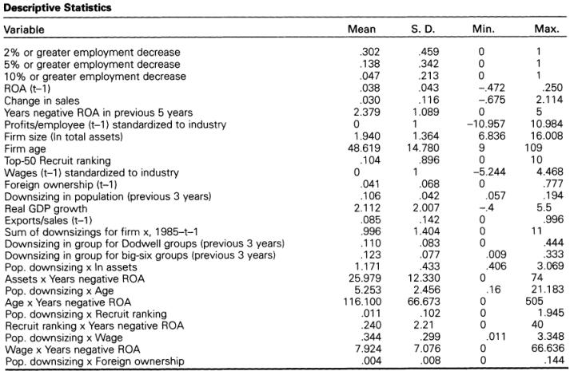

NOTE: complex table shown as an image of the PDF; the text below is a rough machine extraction and may be mis-aligned.

**extracted text (unreliable layout)**

**635/ASQ, December 2001**

Page 15

**Table 3**

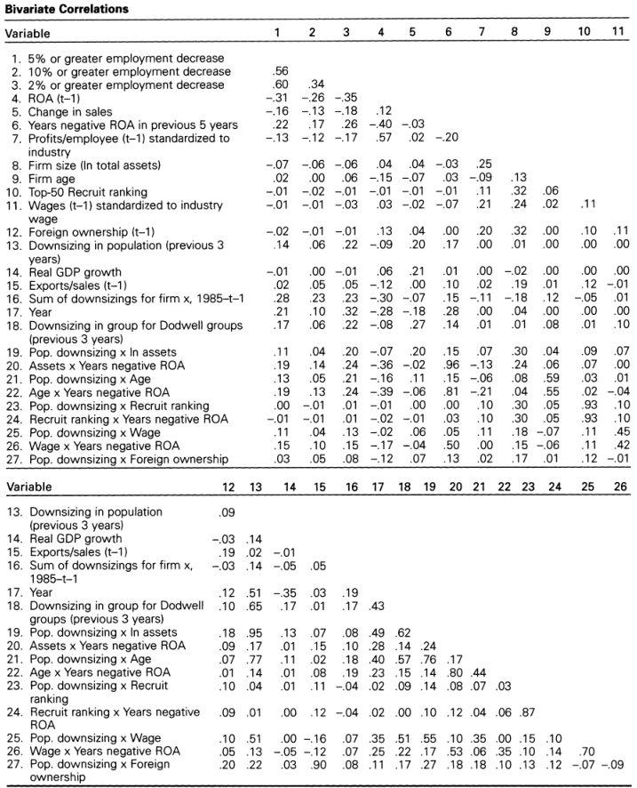

NOTE: complex table shown as an image of the PDF; the text below is a rough machine extraction and may be mis-aligned.

**extracted text (unreliable layout)**

**2 In supplemental analyses, we substituted the log of number of employees in the previous year for assets and found a simi- lar negative and significant relationship between size and downsizing. We also experimented with including a squared term for assets, which would suggest that firm size had a curvilinear relationship to change, but found that logged assets offered the best fit.**

**significant relationship between sales per employee and downsizing.**

**636/ASQ, December 2001**

Page 16

**Safety in Numbers**

**Table 4**

[output not shown]

NOTE: table converted from PDF layout to HTML text; cell boundaries are reconstructed. See PDF if exact alignment matters.

Page 17

**centage of a firm's shares held by foreigners, the more likely it was to downsize, consistent with H2e.**

**Hypothesis 3 predicted that the effect of social and institu- tional constraints on downsizing would diminish as downsiz-**

**ing increased across the population. To test this hypothesis, we added to the model: population downsizing and interac- tions between population downsizing and each of the institu- tional and social constraints examined above. Model 3 in table 4 includes population downsizing and shows that the**

**main effect of population downsizing, without the interaction terms, was positive. Model 4 in table 4 adds an interaction term between assets and population downsizing. Consistent with H3, the more downsizing in the population, the less a firm's size hindered its propensity to downsize. Put another way, the larger the firm, the more likely it was to wait until others had downsized before it downsized itself. Figure 2 illustrates this interaction effect at three size levels: the mean and two standard deviations above and below the mean. The curve depicting the relationship between population downsiz- ing (the x axis) and the probability of a firm downsizing (y axis) is much steeper for large firms than for small firms. The graph indicates that when downsizing levels in the population were low, large firms were less likely to downsize, but as downsizing increased momentum, size ceased to hinder downsizing. Thus, there is qualified support for H2a. Large firms were less likely to downsize when rates of population downsizing were low.**

**Model 4 in table 4 also includes an interaction term between years of negative ROA and assets, which is positive and sig-**

**nificant, indicating that the larger the firm, the more years of poor performance it was willing to endure before downsizing. Even in the presence of this interaction, however, the interac- tion between size and population downsizing remained**

**Figure 2. Interaction between population downsizing in the previous three years and size.**

**0.00 0.05 0.10 0.15 0.20 0.25 0.30 0.00 I l l l l l**

#### **-0.50--**

**-1.00 -U-log assets = 8 :b ,- log assets = 11**

#### **n -2.50 .0**

#### **0- -3.00**

#### **-3.50- Population Downsizing over**

#### **Previous Three Years -4.00 - _**

**638/ASQ, December 2001**

Page 18

**Safety in Numbers**

**strong and significant. This rules out an alternative explana- tion for the diminishing effect of firm size over time: that large firms had deeper pockets and could withstand more years of poor performance before taking action.**

**Model 5 in table 4 examines the interaction between firm age and population downsizing, similarly controlling for the interaction between age and years of poor performance. The older the firm, the more likely it was to wait until others had downsized before downsizing. Figure 3 demonstrates this**

**Figure 3. Interaction between population downsizing in the previous three years and age.**

#### **0.40**

#### **0.20**

**0.00- 0 e e 052 0.30**

#### **-0.60-- .0**

#### **-0.80**

#### **-1.00 Population Downsizing over**

#### **-1.20**

**interaction effect at mean age and two standard deviations above and below the mean. Again, the curve for old firms is steeper than for young firms, indicating a closer relationship between population downsizing and firm downsizing for older firms. Model 6 demonstrates that firms with Recruit endorse-**

**ments were also more likely to follow population downsizing, as were high-wage firms, as shown in model 7. Figures 4 and 5 demonstrate these interaction effects, again, at mean levels and two standard deviations above and below the mean, showing steeper curves for top-ranked firms and high- wage firms.**

**Model 8 in table 4 includes an interaction between population downsizing and foreign ownership. We argued that the more foreign ownership a firm had, the less it was constrained to follow normatively accepted practices and the more likely it was to downsize. Conversely, the more Japanese ownership a firm had, the more it was constrained by prevailing norms around permanent employment and the less likely to down- size. We expected that as Japanese-owned firms found safe- ty in numbers with increasing levels of population downsiz-**

**639/ASQ, December 2001**

Page 19

**Figure 4. Interaction between population downsizing in the previous three years and Recruit ranking.**

#### **2.50 <sup>-</sup>**

#### **2.00 <sup>-</sup>**

#### **1.50-**

#### **1.00- 0n**

**0 > -0.50 0.00 0.05 0.10 0.20 0.25 0.30**

**-> -1.00 - 0**

**CL 4 top ranked -1.50-**

#### **-2.00 <sup>-</sup> / not top ranked**

#### **Population Downsizing over -2.50 Previous Three Years**

#### **-3.00 <sup>-</sup>**

**ing, they would be more likely to downsize and, consequent- ly, that the interaction between foreign ownership and popu- lation downsizing would be negative. In fact, the interaction between foreign ownership and population downsizing was positive, suggesting that firms with foreign ownership became even more likely to downsize as population downsiz- ing increased.**

**Model 9 in table 4 includes all of the interactions between population downsizing and social and institutional constraints**

**Figure 5. Interaction between population downsizing in the previous three years and wage.**

#### **1.40**

#### **1.20**

#### **1.00**

#### **0.80**

#### **B0.60 wage = mean -2 sd 0.6**

#### **D 0.40- wage = mean**

**- 0.20 -/- wage = mean +2 sd ~0**

**0.05 -0.40- .**

#### **Population Downsizing over -0.60 Previous Three Years**

**640/ASQ, December 2001**

Page 20

**3 We conducted several additional analy- ses, available from the authors, to assure that the interaction effects were robust. First, we estimated the interactions between population downsizing and firm size, age, reputation, and wage in models that did not include the interaction between years of negative profitability and each of these measures. The results were similar to those of models that included these interactions. We also con- ducted a set of analyses in which we cen- tered the interaction by subtracting each component of the interaction (e.g., popu- lation downsizing and size) from its mean before multiplying them. Results were unchanged.**

**Safety in Numbers**

**(except foreign ownership), as well as the interaction between years of poor performance and assets. While the size and significance of these interaction effects drop some- what when all are included in the same model, they remain consistent in direction with their effects when entered in the model separately.3**

**Control variables. Several control variables were significant. Year had a positive effect on downsizing, indicating that the propensity to downsize increased with the passage of time. The estimate of GDP growth was also positive and signifi- cant, reflecting the fact that the Japanese economy began to grow again after 1994, just as downsizing began to spread widely. Firms with a large percentage of exports were less**

**likely to downsize. One explanation is that exporters faced considerable cost pressure in 1985 after the yen doubled in value in a short period. Accordingly, they made adjustments in their labor forces before the 1990s recession and were less likely to have over-hired during the bubble years of the late 1980s. In contrast, domestic firms, long insulated from foreign competition, were most badly hit by the 1990s slow- down. Strong and significant effects for industry dummies indicate that the propensity to downsize differed across industries. This may reflect differences in economic condi- tions across industries (separate from firm-specific or macro- economic circumstances), or it may suggest that mimetic or competitive pressures caused firms within the same industry to imitate each other. Finally, the more a firm downsized in the past, the more likely it was to downsize again.**

**Researchers have found that change in organizations, once implemented, becomes familiar and well rehearsed and builds a momentum of its own (Amburgey, Kelly, and Barnett, 1993). Once resistance to a change is overcome, it opens an opportunity for continuous or radical transformation (Tushman and Romanelli, 1985; Greenwood and Hinings, 1988). Consis- tent with this literature, our results suggest that a firm's first downsizing reduced resistance to repeated downsizing. The effect of past downsizing on a firm's propensity to downsize may also mean that firms downsized in increments, spread- ing downsizing over several years.**

#### **Additional Analyses with Alternative Specifications of**

**Downsizing We checked the robustness of our analyses by using alterna- tive specifications of downsizing. Table 5 presents analyses of downsizings of 10 percent or more. Consistent with the previous analyses, performance and foreign ownership trig- gered downsizing, while firm age, Recruit endorsement, and wage levels all inhibited it. Model 3 indicates that the effect of firm size was conditioned by the number of years of nega- tive ROA. Large firms waited for years of poor performance to accumulate before resorting to downsizings of 10 percent or more.**

#### **There is less evidence that population downsizing reduced**

**institutional and social constraints on downsizings of 10 per- cent or more. While the signs of the coefficient estimates were in the predicted direction, they lost significance, with the exception of reputation. This may reflect that even when**

#### **641 /ASQ, December 2001**

Page 21

**Table 5**

#### **Panel Probit Analyses with Robust Standard Errors for Downsizings of 10% or More (N = 13,104 firm-years)***

[output not shown]

NOTE: table converted from PDF layout to HTML text; cell boundaries are reconstructed. See PDF if exact alignment matters.

**Op <sup><</sup>.05; "p <sup><</sup>.01; 'p <sup><</sup>.001 (robust standard errors). *Standard errors are in parentheses; t-tests are one-tailed; coefficients for industry dummy variables are not reported.**

**population downsizing had become widespread, downsizings of 10 percent or more were relatively rare and highly visible actions, and firms were unable to find safety in numbers. In contrast, results for downsizings of 2 percent or more, as shown in table 6, are highly consistent with those for 5-per- cent downsizings.**

**In analyses available separately from the authors, we experi- mented with other specifications of the model and found that our analyses were robust to these specifications as well. An**

**642/ASQ, December 2001**

Page 22

**Safety in Numbers**

**Table 6**

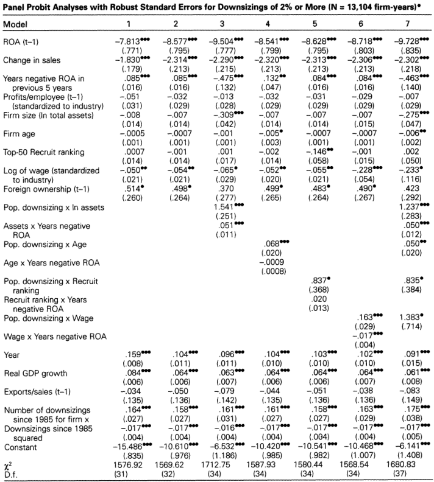

NOTE: complex table shown as an image of the PDF; the text below is a rough machine extraction and may be mis-aligned.

**extracted text (unreliable layout)**

**9p <sup><</sup>.05; Up <sup><</sup>.01; 'p <sup>< .001</sup>(robust <sup>standard errors).</sup> *Standard errors are in parentheses; t-tests are one-tailed; coefficients for industry dummy <sup>variables are not</sup>reported.**

**alternative measure of downsizing, a firm's first downsizing in the 1990s, rendered results quite similar to those in the analyses presented in this paper. We also reestimated the models after replacing the three-year rolling sum of popula- tion downsizing used in this paper with a measure of cumula- tive downsizing in the population since 1990. The results were consistent with those presented here. We then**

**replaced the three-year rolling sum measure with a two-year rolling sum of downsizing and with population downsizing in the previous year, all with similar results.**

**643/ASQ, December 2001**

Page 23

#### **DISCUSSION AND CONCLUSION**

**The economic crisis experienced by Japan in the 1 990s offers researchers a valuable opportunity to examine organi- zational change in highly institutionalized management prac- tices. This paper examined the spread of downsizing and its**

**role in the deinstitutionalization of permanent employment among publicly listed Japanese firms. Our objective was to provide a comprehensive examination of how firms resolved the tension between economic pressures to abandon a high-**

**ly institutionalized practice and social pressures to retain it. We found that poor performance encouraged downsizing, while social and institutional constraints hindered it, particu- larly among more legitimate and more visible firms. Depen- dence on employees with high levels of human capital fur- ther decreased a firm's likelihood of downsizing, while dependence on foreign capital increased it. Our analyses sug- gest, however, that social and institutional concerns gave way to economic pressures as downsizing became increas- ingly widespread across the population, and firms found safe- ty in numbers.**

**Consistent with existing research, we found that economic pressures triggered deinstitutionalization. The lower a firm's profits and sales growth, the more likely it was to downsize. While foreign investors and journalists have criticized Japan- ese firms for not responding quickly enough to economic pressure for change, our analyses suggest that Japanese firms responded to declining profits by reducing their perma- nent labor forces and that these cuts increased throughout the 1 990s. We found that social and institutional constraints slowed downsizing, but the link between poor performance and subsequent downsizing was present from the beginning. We are agnostic on the question of whether downsizing actu- ally improved performance. Studies of U.S. firms demon- strate that downsizing is not the panacea that it is often made out to be, and the effect of downsizing on long-term performance is questionable at best (Cascio, 1993; Budros,**

**1997). But our findings do not hinge on the question of whether downsizing was truly effective or not for Japanese firms. The important point is that Japanese managers**

**believed that downsizing was a necessary and effective means to respond to economic pressures.**

#### **This paper extends research on deinstitutionalization by pay-**

**ing particular attention to the social and institutional pres- sures that hindered downsizing and the circumstances under which these pressures diminished. We found that size, age, reputation, and wage levels all decreased the propensity to downsize, at least in the initial years when population down- sizing rates were still low. Foreign ownership, in contrast, promoted downsizing.**

**There are alternative explanations for the finding that large and old firms were less likely than smaller and newer firms to downsize when downsizing was still relatively infrequent**

**in the population. Because they are highly bureaucratized and settled into familiar and successful routines, large firms have higher levels of inertia (DiMaggio and Powell, 1991; Have- man, 1993b). For these firms, change is difficult to negotiate,**

#### **644/ASO, December 2001**

Page 24

**Safety in Numbers**

**and even threatening to their survival (Hannan and Freeman,**

**1989). Large firms also have deeper pockets and can with- stand declining performance for a longer period before seek- ing change. Older firms tend to resist change for similar rea- sons: they have settled into comfortable routines and stable relationships with their external stakeholders. But our results indicate that the relationship between size and age and downsizing was due to more than inertia. Size and age depressed downsizing rates even when we added interac- tions between size and age and years of negative perfor-**

**mance, capturing the degree to which a firm tended to wait for overwhelming bad news before downsizing. Furthermore,**

**inertia alone does not explain why size and age became less likely to hinder downsizing as population downsizing increased.**

**Highlighting the different institutional environments in which Japanese and U.S. firms are embedded, our results show that large firms in Japan initially resisted downsizing and**

**became more likely to downsize only as downsizing became more widespread across the population. In contrast, Budros (1997) found in his research into downsizing in the U.S. that the larger the American firm, the more likely it was to down- size. He argued that large American firms were more visible and thus were more likely to attract unwanted scrutiny by American shareholders if they did not downsize. Here, the greater visibility of large firms in Japan led to just the oppo- site outcome: large firms avoided downsizing to avoid unwanted scrutiny for adopting an illegitimate practice. While U.S. firms faced a very clear incentive to downsize-share- holders rewarded downsizing with a boost in share price-in Japan, even large institutional shareholders were ambivalent about downsizing and its social impact.**

**Our results also show that foreign investors were less ambivalent than Japanese investors about downsizing. The positive relationship between foreign share ownership and downsizing suggests the important role of global capital mar- kets in spreading new conceptions of management. This finding is also consistent with research suggesting that orga-**

**nizational change comes from players from the outside or at the periphery who hold different notions of how business is done and are less concerned with preserving the status quo (Leblebici et al., 1991; Fligstein, 1996). Although firms with high levels of foreign ownership were more likely than domestic-owned firms to downsize, our finding that popula- tion downsizing increased the effect of foreign ownership on downsizing suggests that foreign-owned firms also sought safety in numbers. More research is merited into how foreign shareholders exerted their influence. One possibility is that the relationship between foreign ownership and increased downsizing occurred only within foreign-controlled firms-in firms with one foreign institution holding 33.4 percent or more (a de facto controlling stake under Japanese commercial law). Another is that foreigners exerted influence even without a controlling stake. Our data set does not distinguish between a foreign-owned firm, such as Mazda, and a firm with a large**

**proportion of foreign ownership, though no single owner,**

#### **645/ASO, December 2001**

Page 25

**such as Sony. Since foreigners controlled only a few publicly listed Japanese companies during this period, however, it is likely that foreigners exerted their influence through other means than direct control.**

**An important focus of this research was to discover how and why the social and institutional constraints that hindered downsizing fell away and allowed downsizing to spread more rapidly across the population. Our empirical results suggest that population downsizing moderated the effect of social and institutional constraints on downsizing. This finding is consistent with a safety-in-numbers effect and suggests that firms waited until others went first to avoid criticism for deviant behavior. The more other firms downsized, the less likely any firm was to be singled out for criticism, the less visible its downsizing would be, and the better it could argue that "everyone else is doing it" to legitimate its behavior to important constituencies.**

#### **An alternative explanation for this finding is that the increas-**

**ing adoption rates of downsizing reflected the increased legit- imacy of downsizing. Organization theorists have argued that firms interpret the increasingly widespread adoption of a new practice as a sign of its legitimacy and adopt the practice themselves to conform to accepted standards of behavior (DiMaggio and Powell, 1983). But there is no reason to believe that downsizing was considered legitimate by any constituency in Japan during this period except by foreign investors. Downsizing and the potential demise of the perma- nent employment system were of great concern to the gen- eral public and to the state, which saw it as a threat to social stability. In the face of this resistance to downsizing among important constituencies, it is difficult to argue that firms would imitate each other to enhance their own legitimacy.**

**Rather, they waited until enough other firms had downsized before downsizing themselves, so as to not stand out and risk losing legitimacy.**

**We further tested the possibility that the increasing legitima- cy of downsizing explained the effect of population-level downsizing by examining the relationship of downsizing to performance over time. Neo-institutional theorists argue that as practices become institutionalized, they become increas- ingly decoupled from economic and technical necessity, and organizations adopt them in order to appear legitimate rather than to solve specific business problems (Tolbert and Zucker,**

**1983). Legitimacy concerns appeared to drive downsizing in the U.S., where increasing rates of downsizing reflected efforts to please shareholders and appear up to date with popular business practices (Budros, 1997). As a result, the business press began to condemn firms for "corporate anorexia" due to over-aggressive downsizing programs (New**

**York Times, June 18, 1996: C1, as cited in Budros, 1997). If Japanese firms similarly imitated others in search of legitima- cy, we should observe that as downsizing increased across the population, it became less related to performance. Sup- plementary analyses, available from the authors, reveal no evidence that the relationship between low profits and poor sales growth and downsizing diminished during this time, as it would if downsizing itself were becoming institutionalized.**

**646/ASQ, December 2001**

Page 26

**Safety in Numbers**

#### **Thus, we conclude that safety in numbers, rather than**

**increased legitimacy of downsizing, is the more likely expla- nation for population-level effects.**

**The safety-in-numbers effect contrasts with studies that demonstrate that organizations imitate larger, higher-status firms (e.g., Haveman, 1993a; Podolny, 1994). This contrast may reflect the fact that processes of interorganizational con- tagion depend on a practice's legitimacy. While organizations imitate larger, higher-status firms when a practice's legitima- cy and efficacy are uncertain, a practice that is considered illegitimate and deviant is likely to spread by other paths (Rogers, 1995). Davis and Greve (1997), for example, attrib- uted the strikingly different diffusion patterns between the poison pill and the golden parachute among American firms to different levels of legitimacy of these two practices. While these authors suggested that firms adopted illegitimate prac- tices out of immediate necessity or for firm-specific, idiosyn- cratic factors, however, our research suggests that even ille- gitimate practices spread through social processes. Practices deemed illegitimate by important stakeholders are likely to spread via safety in numbers, as firms wait for others to go first, and to allow negative publicity to subside, before they act themselves.**

**Our research into the process by which downsizing spread and gained momentum suggests both parallels and points of divergence between deinstitutionalization and institutionaliza- tion. Similar to institutionalization, deinstitutionalization unfolds over time and reflects the interplay of social and eco- nomic pressures. In the course of institutionalization, howev- er, technical and social pressures increasingly become decou- pled as organizations adopt legitimated practices for social rather than technical or efficiency reasons (DiMaggio and Powell, 1983; Tolbert and Zucker, 1983). In contrast, we found that as an illegitimate practice spreads throughout a**

**population, institutional and social constraints fall away. Yet deinstitutionalization is not simply institutionalization's con- verse. While institutionalization progresses as organizations strive for legitimacy, deinstitutionalization progresses as orga- nizations try to balance the perceived benefits of casting aside an institutionalized practice with the social costs of ille- gitimate behavior.**

**Alternative Explanations Our claim that safety in numbers eroded institutional and social constraints against downsizing hinges on our measure of population downsizing. Consequently, it is important to establish that the effect of population downsizing is real and does not simply capture omitted variables that similarly vary with time. While it is impossible to rule out, beyond any doubt, the possibility of omitted variables, we can eliminate some obvious alternatives.**

#### **We controlled for the possibility that worsening macroeco-**

**nomic conditions were responsible for increased downsizing by including GDP growth in our models. Contrary to expecta- tion, GDP growth had a positive effect on downsizing, proba- bly reflecting the fact that as downsizing spread rapidly in**

#### **1995 and 1996, the economy appeared to be recovering**

#### **647/ASQ. December 2001**

Page 27

**(GDP growth dropped again during the second half of the decade). Increasing rates of downsizing also cannot be attrib- uted to growing pessimism about the future of the Japanese economy. Surveys of business sentiment conducted by Japan's Economic Planning Agency indicated that while opti-**

**mism about the prospects for the Japanese economy decreased until 1994, it increased between 1994 and 1995, again experiencing a distinct drop in 1998 and an even sharp- er one in 1999 (Economic Planning Agency, 1998, 1999).**

**Factors external to Japan, for example, a worldwide downsiz- ing boom, provide another possible explanation for increasing rates of downsizing. We controlled for two obvious points of international influence: foreign ownership and exports. We also examined headlines of articles on downsizing and restructuring in the Japanese business press during this peri- od (through the Nikkei Telecom news service) to determine whether reports of U.S. downsizing in the business press also influenced Japanese firms. While downsizing among American companies attracted attention in Japan in the late**

**1 980s, by the 1 990s, reports of downsizing within Japanese firms overshadowed these reports, making it unlikely that**

**increasing reports of downsizing activity in the U.S. stimulat- ed rising downsizing in Japan.**

**We also cannot rule out the possibility that our measure of population downsizing simply reflected the passage of time. This, however, begs the question of what it is about time that causes increased downsizing. We find further evidence that population downsizing and the passage of time do not capture exactly the same thing in the fact that population downsizing and year are not totally correlated (their correla- tion is .51). Additionally, the effect of population downsizing on downsizing remains strong and significant when a contin- uous measure of year is included in the model, suggesting that population downsizing is not simply a proxy for time.**

**Business groups and downsizing. The effect of population downsizing on firm downsizing may mask more fine-grained diffusion processes, such as those through social networks. Numerous researchers have traced the influence of social networks on the diffusion of new practices (Galaskiewicz and Wasserman, 1989; Davis, 1991; Burns and Wholey, 1993;**

**Haunschild, 1993). Social networks are particularly important in Japan, where a dense web of ties, including ownership stakes, interlocking directorships, groupwide councils, and trading relationships, links many firms into business groups (Gerlach, 1992). Thus, the effect of business groups on the spread of downsizing could be important.**

**One of the difficulties of studying Japanese business groups is that it is a non-trivial task to distinguish between group members and independent firms. Even firms that are not offi- cial members of a group's association or president's council often maintain close linkages through ownership ties, trading relationships, and interlocking directorships (Gerlach, 1992). Since we do not have access to such data for all the firms in our sample, we examined group effects among firms listed as members of 19 major business groups listed in Industrial**

#### **Groupings in Japan (Dodwell, 1990/91), a well-known guide**

**648/ASQ, December 2001**

Page 28

**4 Groups listed by Dodwell include mem- bers of the "big six" horizontal groups of large corporations in different industries (Mitsui, Mitsubishi, Sumitomo, Fuyo, Sanwa, and DKB). Dodwell also lists important members of vertical groups of manufacturers and affiliated suppliers and distributors, such as the Toyota and Nip- pon Steel Groups, as well as several groups made up of railroads and affiliated real estate and retail outlets and other sets of affiliated firms.**

**Safety in Numbers**

**to group affiliations.4 We measured group downsizing in the same way as population downsizing: the sum of the number of members of the same group that downsized over the pre- vious three years, minus downsizings by the focal firm, divid- ed by the number of firms in the group minus the focal firm, multiplied by three.**

**Table 7 presents analyses of downsizing among firms known to belong to groups. Model 1 includes firm-level and popula- tion-level variables, as in previous analyses. Model 2 adds group downsizing. Group downsizing did not add to the explanatory power of model 2, and population downsizing remained large and significant. While group downsizing was not significant, it was positive, suggesting a possible relation- ship between group and firm downsizing. The important point for this paper, however, is that our measure of popula- tion downsizing did not simply mask more complex, group- level effects.**

**Table 7**

**Panel Probit Analyses with Robust Standard Errors for Downsizings of 5% or More in 261 Group Firms (N = 2088 firm-years)***

[output not shown]

NOTE: table converted from PDF layout to HTML text; cell boundaries are reconstructed. See PDF if exact alignment matters.

**Op <sup><</sup>.05; 'p <sup><</sup>.01; Up <sup>< .001</sup>(robust <sup>standard</sup>errors). *Standard errors are in parentheses; t-tests are one-tailed; <sup>coefficients for</sup> industry dummy variables are not reported.**

#### **6491ASQ, December 2001**

Page 29

**5 While these major downsizings, and an increase in the unemployment rate to 5 percent in 2001, led to much commentary in the media about how the Japanese economy would absorb increasing num- bers of unemployed, little to no criticism was directed at the companies that had downsized.**

**Downsizing and the Future of Permanent Employment We predict that even when economic conditions improve, and when an aging population reverses the problem of excess labor to one of labor shortage, Japanese firms will not revert to the permanent employment system as it existed in the 1980s. While Japanese firms may never develop a taste for American-style mass layoffs, and while many employees**

**may continue to enjoy long-term careers with the same firm, we believe that downsizing in the 1 990s effectively deinstitu- tionalized permanent employment. As we noted earlier, downsizings affected the loyalty of the remaining employees, and it is difficult to see how firms can enjoy the same level of employee commitment as under the permanent employ- ment system. Downsizings also affected the loyalty of new hires: a generation of employees, raised on a diet of news reports of firms reconsidering the permanent employment system, is likely to think twice before committing to a life- time at a company. Even if firms do regain employee loyalty, reduced hiring in many firms has eliminated a whole cohort of new employees. When this hole in the career ladder hits middle management levels, firms will be forced to resort to mid-career hiring, further eroding an important pillar of the permanent employment system.**

**There is evidence that the process of deinstitutionalization of permanent employment has continued through the end of the twentieth century and into the early years of the new mil-**

**Limitations and Suggestions for Further Research This research has a number of limitations. While some are difficult to surmount, others suggest some very interesting avenues for future research. Although it would be interesting to be able to distinguish between different methods of down- sizing-early retirements, transfers, reduced hiring, and out- right layoffs-firms do not report these data publicly, and their sensitive nature makes it difficult to obtain them through surveys. Even though more fine-grained data would give us more detailed insights into the specific process of downsizing, we do not believe that they would significantly change our basic conclusions about the role of downsizing in the deinstitutionalization of permanent employment. As we noted previously, all of these means of downsizing signaled discontinuities with the existing system of permanent employment. As Usui and Colignon (1996: 565) noted in their study of downsizing in Japan in the early 1990s, "These**

**650/ASQ, December 2001**

Page 30

**Safety in Numbers**

**employment strategies are drastic to the Japanese, because large companies have not taken such measures in postwar Japan, Japanese perceive these events as unthinkable, dis- graceful, and even shameful on the part of the companies."**

**Another limitation of our research concerns our measure of population-level downsizing. As with any research that relies on population-level variables, it is simply impossible to com- pletely rule out that another factor correlated with population- level downsizing is really responsible for the empirical results. We tried to eliminate the most plausible alternatives, but it is impossible to completely rule out all alternatives. We believe, however, that this offers an opportunity for future research using different research methods. Qualitative research would be particularly helpful in providing support for our arguments on how safety in numbers promoted the spread of downsizing. For example, a detailed analysis of newspaper reports on downsizing during this period would help us to better understand just how and why firms' fears of negative publicity faded as downsizing gained momentum across the population. An analysis of newspaper reports is also likely to offer further insight into the degree to which permanent employment was deinstitutionalized during this period. Particularly interesting would be an analysis of rhetoric tying permanent employment to widely held Japan- ese values and virtues and the degree to which this rhetoric waned as downsizing progressed in the 1990s.**

**Only the passage of time will remedy another limitation. The story that we tell in this paper is an unfinished one. While permanent employment was increasingly deinstitutionalized in the 1990s, and reports of widespread layoffs in 2001 sug- gest that this process has accelerated, we do not yet know how the story will end. Regardless of the eventual outcome, the transformation of the world's second largest economy in the face of increasing globalization of capital, products, and management ideas is an issue of the utmost importance for management theorists, managers, and government officials in Japan, the U.S., and around the world. As we hope we have demonstrated in this paper, organizational theory, and institutional theory in particular, offer a particularly useful set of tools for understanding how external pressures and inter- nal sources of resistance combine to shape population-level organizational change.**

**Finally, the implications of this research go beyond Japan. Economic crisis in a global economy has forced Japanese firms to confront the unpleasant prospect of dismantling the**

**permanent employment system. While a country insulated from the outside world might be able to protect its domestic employment practices, those that are struggling with global competition and global markets no longer have this luxury. This dilemma is not unique to Japan and will increasingly be faced by other firms and economies heavily exposed to the international marketplace. Studies of how firms address this challenge will provide important insight into the processes of organizational transformation in an increasingly global economy.**

#### **651/ASQ. December 2001**

Page 31

#### **REFERENCES**

**Abegglen, J. C.**

**1958 The Japanese Factory. New York: Free Press.**

**Abegglen, J. C., and G. Stalk, Jr.**

**1985 Kaisha: The Japanese Corpo- ration. New York: Basic Books.**

**Allison, P. D.**

**1984 Event History Analysis: Regression for Longitudinal Data. Newbury Park, CA: Sage.**

**Amburgey, T. L., D. Kelly, and W.**

**Barnett 1993 "Resetting the clock: The dynamics of organizational change and failure." Adminis- trative Science Quarterly, 38: 51-73.**

**Aoki, M.**

**1988 Information, Incentives, and Bargaining in the Japanese Economy. Cambridge: Cam- bridge University Press.**

**Asahi Shimbun 2001 "Kouroushou 'kaikou ruuru' o kentou e" [Ministry of Health, Labor and Welfare to recon- sider firing rules]. www.asahi.com. Sept. 27. Viewed 9/27/01.**

**Bank of Japan 1994 Waga Kuni no Koyou Shisute- mu ni Tsuite [About the employment system of Japan]. Tokyo: Bank of Japan, Chousa Toukei Kyoku.**

**Becker, G. S. 1993 Human Capital: A Theoretical and Empirical Analysis. Chica- go: University of Chicago Press.**

**Boeker, W. 1989 "The development and insti- tutionalization of subunit power in organizations." Administrative Science Quar- terly, 34: 388-410.**

**Brown, C., Y. Nakata, M. Reich, and L. Ullman 1997 Work and Pay in the United States and Japan. New York: Oxford University Press.**

**Budros, A. 1997 "The new capitalism and organizational rationality: The adoption of downsizing pro- grams, 1979-1994." Social Forces, 76: 229-250.**

**Burns, L. R., and D. R. Wholey 1993 "Adaptation and abandon- ment of matrix management programs: Effects of organiza- tional characteristics and interorganizational networks." Academy of Management Journal, 36: 106-138.**

**Cascio, W.**

**1993 "Downsizing: What do we know? What have we learned?" Academy of Man- agement Executive, 7 (1): 95-104.**

**Chandler, A.**

**1962 Strategy and Structure: Chap- ters in the History of the American Business Enter- prise. Cambridge, MA: MIT Press.**

**Clark, R.**

**1979 The Japanese Company. New Haven, CT: Yale University Press.**

**Cole, R. E.**

#### **1979 Work, Mobility and Participa- tion: A Comparative Study of American and Japanese**

**Industry. Berkeley: University of California Press.**

**D'Aunno, T., M. Succi, and J. A. Alexander 2000 "The role of institutional and market forces in divergent organizational change." Administrative Science Quar- terly, 45: 679-703.**

**Davis, G. F. 1991 "Agents without principles? The spread of the poison pill through the intercorporate network." Administrative Sci- ence Quarterly, 36: 583-613.**

**Davis, G. F., K. A. Diekmann, and C. H. Tinsley 1994 "The decline and fall of the conglomerate firm in the**

**1 980s: The deinstitutionaliza- tion of an organizational form." American Sociological Review, 59: 547-570.**

**Davis, G. F., and H. R. Greve 1997 "Corporate elite networks and governance changes in the 1 980s." American Journal of Sociology 103: 1-37.**

**Deephouse, D. 1996 "Does isomorphism legiti- mate?" Academy of Manage- ment Journal, 39: 1024-1039.**

**DiMaggio, R 1988 "Interest and agency in insti- tutional theory." In L. G. Zuck- er (ed.), Institutional Patterns and Organizations: Culture and Environments: 3-21. Cambridge, MA: Ballinger.**

#### **DiMaggio, P. J., and W. W. Powell**

**1983 "The iron cage revisited: Insti- tutional isomorphism and col- lective rationality in organiza- tional fields." American Sociological Review, 48: 147-160. 1991 "Introduction." In W. W. Powell and P. J. DiMaggio (eds.), The New Institutional- ism in Organizational Analy- sis: 1-38. Chicago: University of Chicago Press.**

#### **Dodwell Marketing Consultants 1990/91 Industrial Groupings in Japan: The Anatomy of the**

**"Keiretsu." Chicago: Tech- nomic Dodwell Consultants.**

**Dore, R. 1973 British Factory Japanese Fac- tory: The Origins of National Diversity in Industrial Rela- tions. Berkeley: University of California Press. 1986 Flexible Rigidities: Industrial Policy and Structural Adjust- ment in the Japanese Econo- my 1970-80. London: Athlone Press.**

#### **Economic Planning Agency**

**1998 Heisei 10 mendo kigyou koudou ni kansuru ankeeto chousa [A survey of corporate activity for 19981. Tokyo: Eco- nomic Planning Agency. 1999 Heisei 1 1 nendo kigyou koudou ni kansuru ankeeto chousa [A survey of corporate activity for 19991. Tokyo: Eco- nomic Planning Agency.**

**Eisenstodt, G. 1995 "Job shokku." Forbes, 156 (Jul. 31): 42-43.**

**Elsbach, K. D., and R. I. Sutton 1992 "Acquiring organizational legitimacy through illegitimate actions: A marriage of institu- tional and impression man- agement theories." Academy of Management Journal, 35: 699-738.**

**Fligstein, N. 1996 "Markets as politics: A politi- cal-cultural approach to mar- ket institutions." American Sociological Review, 61: 656-673.**

**652/ASQ, December 2001**

Page 32

**Safety in Numbers**

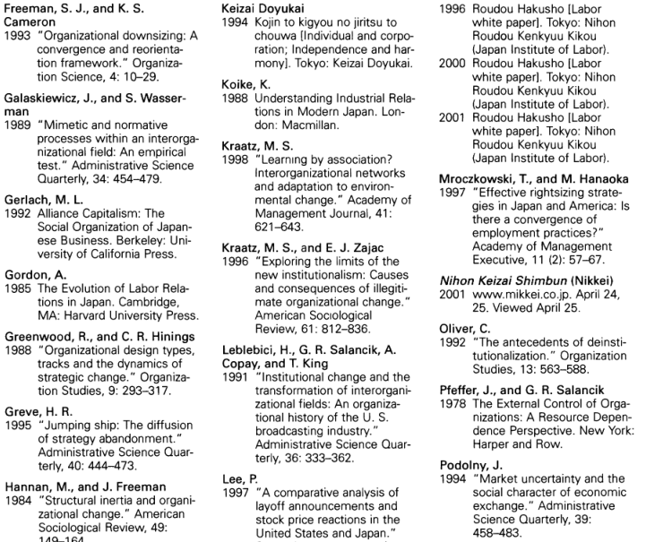

NOTE: complex table shown as an image of the PDF; the text below is a rough machine extraction and may be mis-aligned.

**extracted text (unreliable layout)**

**Hannan, M., and J. Freeman 1984 "Structural inertia and organi- zational change." American Sociological Review, 49: 149-164. 1989 Organizational Ecology. Cam- bridge, MA: Harvard Universi- ty Press.**

**Haunschild, R R. 1993 "Interorganizational imitation: The impact of interlocks on corporate acquisition activity." Administrative Science Quar- terly, 38: 564-592.**

**Haveman, H. A. 1993a "Follow the leader: mimetic isomorphism and entry into new markets." Administrative Science Quarterly, 38: 593-628. 1993b"Organizational size and change: Diversification in the savings and loan industry after deregulation." Adminis- trative Science Quarterly, 38: 20-50.**

**Kang, J. K., and A. Shivdasani 1997 "Corporate restructuring dur- ing performance declines in Japan." Journal of Financial**

**Economics, 46: 29-65.**

**Liang, K. Y., and S. L. Zeger 1986 "Longitudinal data analysis using generalized linear mod- els." Biometrika, 73: 13-22.**

**LTCBR Consulting, Inc. 1998 "21 Seiki no cooporeeto shisutemu ni kansuru ankeeto chousa" [A survey of the 21 century corporate system]. Tokyo: LTCBR Consulting, Inc.**

**Meyer, J. W., and B. Rowan 1977 "Institutionalized organiza- tions: Formal structure as myth and ceremony." Ameri- can Journal of Sociology, 83: 340-363.**

#### **Miller, D., and P H. Friesen 1984 Organizations: A Quantum View. Englewood Cliffs, NJ:**

**Prentice-Hall.**

**Ministry of Labor, Japan 1995 Sangyou Roudou Shijou Chousa Kekka Sokuhou [Report <sup>on a</sup>survey <sup>of indus-</sup> trial labor conditions]. Tokyo:**

**Ministry of Labor.**

**Rohlen, T. 1974 For Harmony and Strength Japanese White-collar Organi- zation in Anthropological Per- spective. Berkeley: University of California Press. 1983 Japan's High Schools. Berke- ley: University of California Press.**

**Rogers, E. 1995 Diffusion of Innovations. New York: Free Press.**

**Ruef, M., and W. R. Scott 1998 "A multidimensional model of organizational legitimacy: Hospital survival in changing institutional environments." Administrative Science Quar- terly, 43: 877-904.**

**Salancik, G. R. 1979 "Interorganizational depen- dence and responsiveness to affirmative action: The case of women and defense con- tractors." Academy of Man- agement Journal, 22: 375-394.**

**653/ASQ, December 2001**

Page 33

| Scott W R , . . 1995 Institutions and Organizations. Thousand Oaks, CA: Sage. | Tokyo Stock Exchange 2001 "2000 shareownership sur- vey." Tokyo: Tokyo Stock | Useem, M . 1996 InvestorCapitalism:How Money Managers Are Chang- |
| --- | --- | --- |
| Selznick R , 1957 Leadership in Administration. Evanston, IL: Row, Peterson. | Exchange. Tolbert R S and L G Zucker , ., . . 1983 "Institutionalsources of | ingthe Faceof Corporate America. New York:B asic Books/HarperCollins. |
| Sheard R , 1991 "Theroleoffirmorganization in the adjustment of a declin- ingindustryinJapan:The case of aluminum." Journal of the Japanese and Internation- | change inthe formalstructure oforganizations:Thediffusion of civil service reforms, 1880 -1935 ." Administrative Science Quarterly, 28: 22 -39 . Thomson, R . | Usui C and R Colignon , ., . 1996 "Corporaterestructuring: Convergingworldpatternor societally specific embedded - ness?" Sociological Quarterly, 4: 351 -378 . |
| al Economies, 5:14 -40 . | 1993 "Pioneershakes Japanese | Vogel E F , . . |
| Suchman, M . 1995 "Managing legitimacy: Strate- gic and institutional approach - | faith in jobs-for-life system." Financial Times, Jan. 9: 24 . Tushman, M L and R Anderson . ., | 1979 Japanas #1: Lessons for America. Cambridge, MA: Harvard University Press. |
| es." Academy of Manage- ment Review, 20: 571 -610 . | 1986 "Technologicaldiscontinuities and organizational environ- | White, H . 1980 "A heteroskedasticity-consis- |
| Sugeno, K . 1992 Japanese Labor Law. Seattle, WA:UniversityofWashington Press. | ments." Administrative Sci - ence Quarterly, 31: 439 -465 . Tushman, M L and E Romanelli . ., . 1985 "Organizationalevolution:A | tent covariance matrix estima- tor and a direct test for het- eroskedasticity. " Econometrica, 48: 817 -830 . |
| Taira, K . 1970 Economic Development and the Labor Market in Japan. New York: Columbia Universi - ty Press. | metamorphosis model of con- vergence and reorientation." In L L Cummings and B M . . . . Staw (eds.) Research in , Organizational Behavior, 7: 171 -222 Greenwich CT:J AI . , Press. | Yamaguchi K , . 1991 Event History Analysis. New- bury Park CA: Sage. , |

NOTE: table converted from PDF layout to HTML text; cell boundaries are reconstructed. See PDF if exact alignment matters.

**654/ASQ, December 2001**